# Final Report

2024-12-18

## 1. Data Description

This data set was collected to study gasoline consumption of cars. There are 30 models of cars included in the data. The response variable is the gasoline consumption measured in miles per gallon each year.

The predictors include 11 measurements:  
- X1 Displacement (cubic inches)  
- X2 Horsepower (feet/pound)  
- X3 Torque (feet/pound)  
- X4 Compression ratio  
- X5 Rear axle ratio  
- X6 Carburetor (barrels)  
- X7 Number of transmission speeds  
- X8 Overall length (inches)  
- X9 Width (inches)  
- X10 Weight (pounds)  
- X11 Type of transmission (1=automatic; 0=manual)

Data Summary:

```
##        Y               X1              X2              X3
##  Min.   :11.20   Min.   : 85.3   Min.   : 70.0   Min.   : 81.0
##  1st Qu.:16.43   1st Qu.:226.5   1st Qu.:106.0   1st Qu.:171.2
##  Median :19.30   Median :318.0   Median :141.5   Median :243.0
##  Mean   :20.04   Mean   :285.7   Mean   :137.0   Mean   :217.9
##  3rd Qu.:21.50   3rd Qu.:351.0   3rd Qu.:165.0   3rd Qu.:258.8
##  Max.   :36.50   Max.   :500.0   Max.   :223.0   Max.   :366.0
##        X4              X5              X6              X7
##  Min.   :8.000   Min.   :2.450   Min.   :1.000   Min.   :3.000
##  1st Qu.:8.000   1st Qu.:2.710   1st Qu.:2.000   1st Qu.:3.000
##  Median :8.325   Median :3.000   Median :2.000   Median :3.000
##  Mean   :8.313   Mean   :3.059   Mean   :2.567   Mean   :3.333
##  3rd Qu.:8.500   3rd Qu.:3.243   3rd Qu.:4.000   3rd Qu.:3.000
##  Max.   :9.000   Max.   :4.300   Max.   :4.000   Max.   :5.000
##        X8              X9             X10            X11
##  Min.   :155.7   Min.   :61.80   Min.   :1905   Min.   :0.0000
##  1st Qu.:173.4   1st Qu.:65.78   1st Qu.:3028   1st Qu.:0.2500
##  Median :196.1   Median :72.00   Median :3760   Median :1.0000
##  Mean   :192.3   Mean   :71.42   Mean   :3626   Mean   :0.7333
##  3rd Qu.:207.1   3rd Qu.:76.30   3rd Qu.:4215   3rd Qu.:1.0000
##  Max.   :231.0   Max.   :79.80   Max.   :5430   Max.   :1.0000
```

```
## 'data.frame':    30 obs. of  12 variables:
##  $ Y  : num  18.9 17 20 18.3 20.1 11.2 22.1 21.5 34.7 30.4 ...
##  $ X1 : num  350 350 250 351 225 440 231 262 89.7 96.9 ...
##  $ X2 : int  165 170 105 143 95 215 110 110 70 75 ...
##  $ X3 : int  260 275 185 255 170 330 175 200 81 83 ...
##  $ X4 : num  8 8.5 8.25 8 8.4 8.2 8 8.5 8.2 9 ...
##  $ X5 : num  2.56 2.56 2.73 3 2.76 2.88 2.56 2.56 3.9 4.3 ...
##  $ X6 : int  4 4 1 2 1 4 2 2 2 2 ...
##  $ X7 : int  3 3 3 3 3 3 3 3 4 5 ...
##  $ X8 : num  200 200 197 200 194 ...
##  $ X9 : num  69.9 72.9 72.2 74 71.8 69 65.4 65.4 64 65 ...
##  $ X10: int  3910 3860 3510 3890 3365 4215 3020 3180 1905 2320 ...
##  $ X11: int  1 1 1 1 0 1 1 1 0 0 ...
```

## 2. Fit a Linear Regression Model

```r
data <- read.table("~./STAT452FinalData.txt", header = TRUE)
data$X11 <- factor(data$X11, levels = c(0, 1), labels = c("Manual", "Automatic"))
Y <- data[,1]
fit1 <- lm(Y ~ X1 + X2 + X3 + X4 + X5 + X6 + X7 + X8 + X9 + X10 + X11, data = data)
summary(fit1)
```

```
##
## Call:
## lm(formula = Y ~ X1 + X2 + X3 + X4 + X5 + X6 + X7 + X8 + X9 +
##     X10 + X11, data = data)
##
## Residuals:
##     Min      1Q  Median      3Q     Max
## -5.3498 -1.6236 -0.6002  1.5155  5.2815
##
## Coefficients:
##               Estimate Std. Error t value Pr(>|t|)
## (Intercept)  17.773204  30.508775   0.583   0.5674
## X1           -0.077946   0.058607  -1.330   0.2001
## X2           -0.073399   0.088924  -0.825   0.4199
## X3            0.121115   0.091353   1.326   0.2015
## X4            1.329034   3.099535   0.429   0.6732
## X5            5.975989   3.158647   1.892   0.0747 .
## X6            0.304178   1.289094   0.236   0.8161
## X7           -3.198576   3.105435  -1.030   0.3167
## X8            0.185362   0.129252   1.434   0.1687
## X9           -0.399146   0.323812  -1.233   0.2336
## X10          -0.005193   0.005893  -0.881   0.3898
## X11Automatic  0.598655   3.020681   0.198   0.8451
## ---
## Signif. codes:  0 '***' 0.001 '**' 0.01 '*' 0.05 '.' 0.1 ' ' 1
##
## Residual standard error: 3.226 on 18 degrees of freedom
## Multiple R-squared:  0.8353, Adjusted R-squared:  0.7346
## F-statistic: 8.297 on 11 and 18 DF,  p-value: 5.287e-05
```

The R-squared value states that 83.5% of the variability in MPG is explained by the predictors. The adjusted R-squared still suggests that the model is a good fit, but the high p-values of the predictors suggest that they are not significant. This means that the model is likely overfitted due to the large number of predictors. The following steps will determine the most significant predictors and seek to improve the model using this knowledge.  
Note: as predictor X11 is categorical it has been reinterpreted to correctly reflect its importance to the model.

## 3. Choose the best model using stepwise selection method.

AIC was chosen as the selection criteria.

```r
library(MASS)
data_frame <- data.frame(Y = data$Y, data[,-1])
full_model <- lm(Y~., data=data)
null_model <- lm(Y~1, data = data)
step_model <- stepAIC(null_model, scope=list(lower = null_model, upper = full_model),  direction = "both")
```

```
## Start:  AIC=111.06
## Y ~ 1
##
##        Df Sum of Sq     RSS     AIC
## + X1    1    864.53  272.91  70.238
## + X10   1    826.77  310.66  74.125
## + X3    1    820.52  316.91  74.723
## + X2    1    721.71  415.72  82.865
## + X9    1    661.23  476.20  86.939
## + X8    1    643.90  493.53  88.012
## + X11   1    592.41  545.02  90.989
## + X7    1    569.95  567.49  92.201
## + X5    1    458.98  678.46  97.559
## + X6    1    253.32  884.12 105.502
## + X4    1    202.96  934.48 107.164
## <none>              1137.43 111.060
##
## Step:  AIC=70.24
## Y ~ X1
##
##        Df Sum of Sq     RSS     AIC
## + X4    1     17.93  254.97  70.199
## <none>               272.91  70.238
## + X6    1     14.25  258.66  70.629
## + X9    1     13.30  259.60  70.739
## + X3    1      9.85  263.05  71.135
## + X10   1      5.81  267.10  71.593
## + X2    1      5.46  267.45  71.632
## + X5    1      5.15  267.76  71.666
## + X7    1      3.45  269.46  71.856
## + X11   1      0.04  272.87  72.234
## + X8    1      0.01  272.89  72.237
## - X1    1    864.53 1137.43 111.060
##
## Step:  AIC=70.2
## Y ~ X1 + X4
##
##        Df Sum of Sq    RSS     AIC
## <none>              254.97  70.199
## - X4    1     17.93 272.91  70.238
## + X9    1      8.71 246.27  71.157
## + X3    1      6.45 248.52  71.430
## + X6    1      5.77 249.20  71.512
## + X10   1      4.16 250.81  71.705
## + X2    1      3.36 251.62  71.802
## + X5    1      1.48 253.49  72.024
## + X11   1      1.15 253.83  72.064
## + X7    1      0.05 254.93  72.193
## + X8    1      0.02 254.96  72.197
## - X1    1    679.50 934.48 107.164
```

```r
final_model <- step_model
summary(final_model)
```

```
##
## Call:
## lm(formula = Y ~ X1 + X4, data = data)
##
## Residuals:
##    Min     1Q Median     3Q    Max
## -6.494 -2.123 -0.367  1.968  6.968
##
## Coefficients:
##              Estimate Std. Error t value Pr(>|t|)
## (Intercept)  7.601491  18.846223   0.403     0.69
## X1          -0.044527   0.005249  -8.483 4.28e-09 ***
## X4           3.026924   2.196603   1.378     0.18
## ---
## Signif. codes:  0 '***' 0.001 '**' 0.01 '*' 0.05 '.' 0.1 ' ' 1
##
## Residual standard error: 3.073 on 27 degrees of freedom
## Multiple R-squared:  0.7758, Adjusted R-squared:  0.7592
## F-statistic: 46.72 on 2 and 27 DF,  p-value: 1.709e-09
```

## 4. Check if there is any outlier.

Methods used include Cook’s Distance and R-Student residuals to test for influential points.

```r
library(car)
```

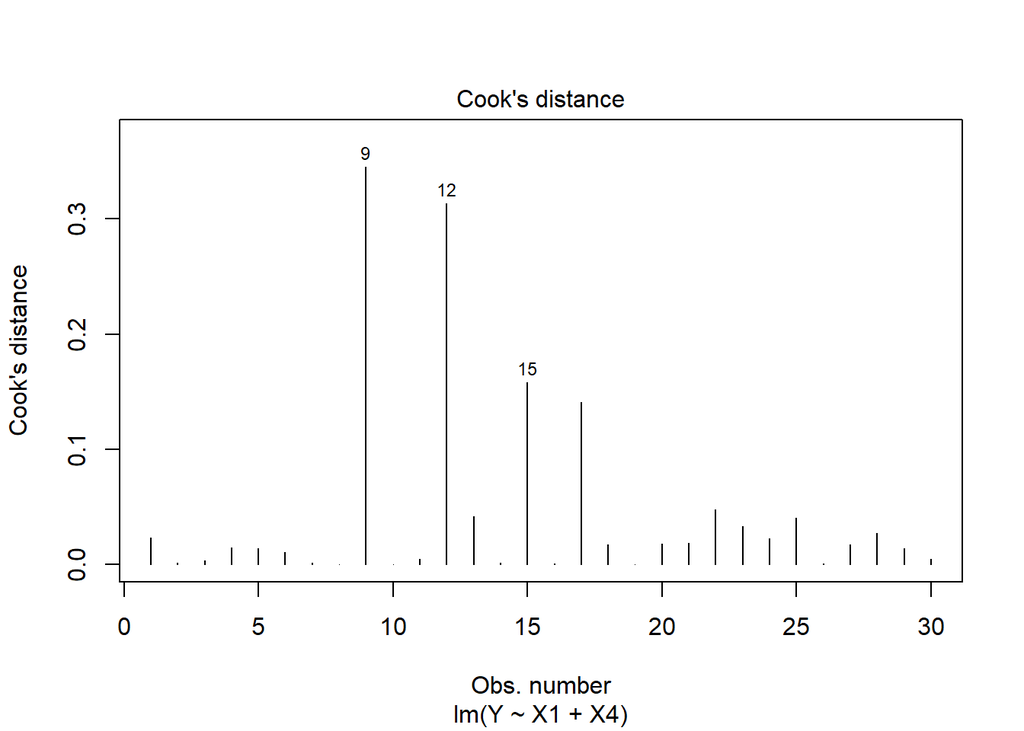

```r
plot(final_model, which = 4)  # Cook's Distance
```

```r
qt(1-0.05/(2*30), df.residual(final_model))
```

```
## [1] 3.492178
```

```r
RStudent <- rstudent(final_model)
outlierTest(final_model) #no outlier detected
```

```
## No Studentized residuals with Bonferroni p < 0.05
## Largest |rstudent|:
##    rstudent unadjusted p-value Bonferroni p
## 12 2.711851           0.011702      0.35106
```

The results of the Cook’s distance graph show all the distance to be less than 1 which indicates there is not any influential points. The Bonferroni Outlier Test produces results that indicate there are no significant outliers as no points have an adjusted p-value of less than 0.05.

## 5. Tests on assumptions

Start by checking for a linear relationship between the response and regressors.

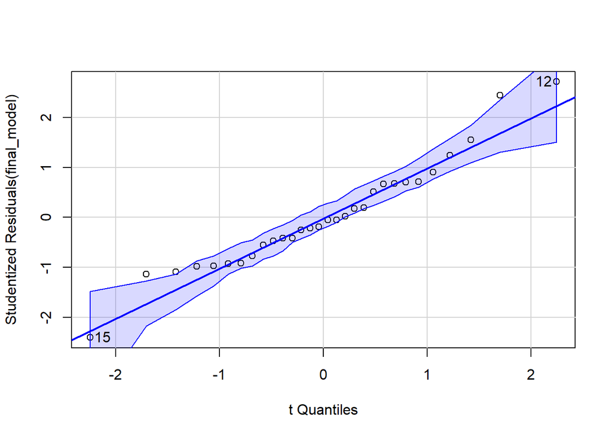

```
## [1] 12 15
```

```r
#Check for a linear relationship between the response and regressors
qqPlot(final_model)
```

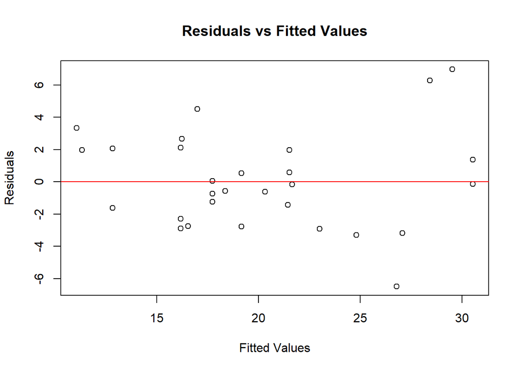

```r
plot(fitted(final_model), resid(final_model),
     xlab = "Fitted Values",
     ylab = "Residuals",
     main = "Residuals vs Fitted Values")
abline(h = 0, col = "red")
```

The qq plot checks for normality and the results of the plot indicate that there could be a positive skew. The plot of residuals vs. fitted values indicates that there could be a funnel pattern to the values. This suggests that the model is linear, but the variance is an increasing function of y. The next test is to check for the constant error variance assumptions which should help prove this conclusion.

```r
#Test for constancy of Error Variance
#Breusch-Pagan test
ncvTest(final_model)
```

```
## Non-constant Variance Score Test
## Variance formula: ~ fitted.values
## Chisquare = 5.918312, Df = 1, p = 0.014984
```

Since the p-value is less than 0.05 the test determines that there is a non-constant error variance which will need to be remedied using transformations.  
The following Durbin-Watson test is used to detect the presence of autocorrelation and randomness.

```r
#Test to see if errors are uncorrelated
durbinWatsonTest(final_model, alternative="two.sided")
```

```
##  lag Autocorrelation D-W Statistic p-value
##    1     -0.01523222      1.996468   0.984
##  Alternative hypothesis: rho != 0
```

Since the p-value of the test is greater than 0.05, the residuals are not correlated.  
The Shapiro-Wilk test is used to test for normality. Since the p-value is greater than 0.05 the residuals appear to be normal.

```r
#Test to see if errors are normally distributed
shapiro.test(RStudent)
```

```
##
##  Shapiro-Wilk normality test
##
## data:  RStudent
## W = 0.9565, p-value = 0.2514
```

The last check is to check for multicollinearity using variance inflation factors. If the VIF values are above 10, there are problems with linear dependencies on some of the regressors.

```r
#Test that the regressors are linearly independent
vif(final_model)
```

```
##       X1       X4
## 1.139226 1.139226
```

Since neither regressor has a VIF value greater than 10, there does not appear to be an issue with multicollinearity.

## 6. Make transformations to fix non-constant variance.

After performing the above tests the only problem appears to be the non-constant variance in error. A box-cox transformation of y will be used to correct the nonconstant variance.

```r
myboxcox <- boxCox(data$Y ~ data$X1 + data$X4, lambda=seq(-2,2,0.1))
```

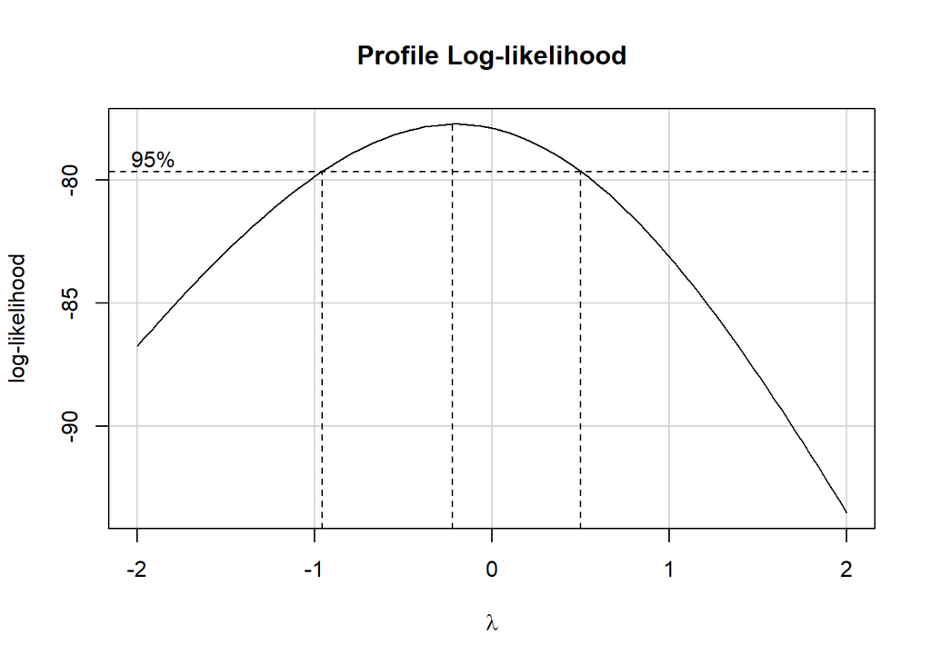

```r
myboxcox$x[which.max(myboxcox$y)]
```

```
## [1] -0.2222222
```

The lambda value for the power transformation is found to be -0.222.

```r
lambda <- -0.22
data$Y_transformed <- (data$Y^lambda - 1) / lambda

final_model_transformed <- lm(data$Y_transformed ~ data$X1 + data$X4, data = data)
summary(final_model_transformed)
```

```
##
## Call:
## lm(formula = data$Y_transformed ~ data$X1 + data$X4, data = data)
##
## Residuals:
##       Min        1Q    Median        3Q       Max
## -0.129854 -0.051338  0.003841  0.041404  0.137315
##
## Coefficients:
##               Estimate Std. Error t value Pr(>|t|)
## (Intercept)  1.9673228  0.4275992   4.601  8.9e-05 ***
## data$X1     -0.0010806  0.0001191  -9.073  1.1e-09 ***
## data$X4      0.0613612  0.0498384   1.231    0.229
## ---
## Signif. codes:  0 '***' 0.001 '**' 0.01 '*' 0.05 '.' 0.1 ' ' 1
##
## Residual standard error: 0.06972 on 27 degrees of freedom
## Multiple R-squared:  0.7945, Adjusted R-squared:  0.7793
## F-statistic: 52.21 on 2 and 27 DF,  p-value: 5.269e-10
```

The model summary shows that the Adjusted R-square improved from the original model’s 0.76 to 0.78.

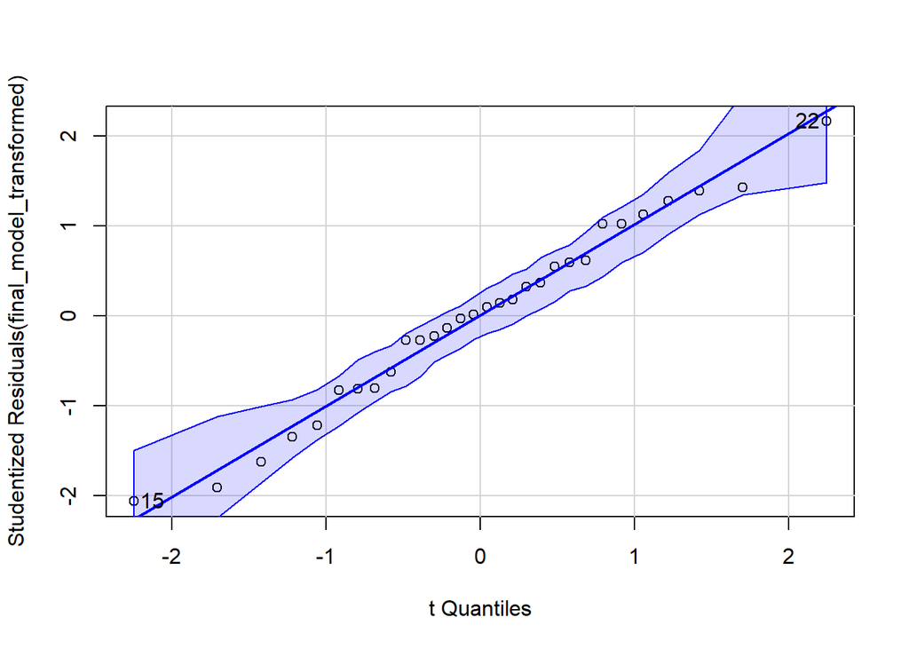

```
## [1] 15 22
```

```r
qqPlot(final_model_transformed)
```

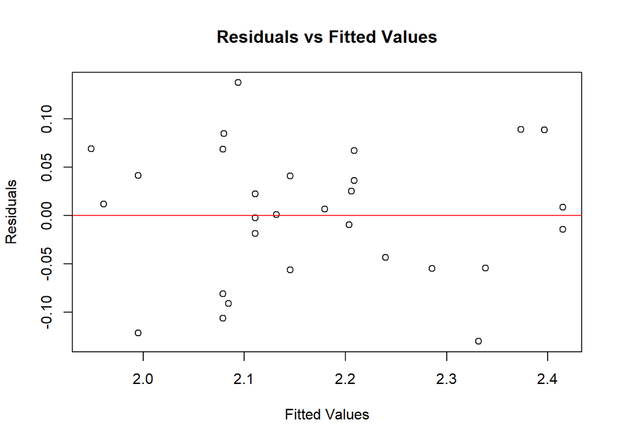

```r
plot(fitted(final_model_transformed), resid(final_model_transformed),
     xlab = "Fitted Values",
     ylab = "Residuals",
     main = "Residuals vs Fitted Values")
abline(h = 0, col = "red")
```

```r
#Test for constancy of Error Variance
#Breusch-Pagan test
ncvTest(final_model_transformed) #reject null
```

```
## Non-constant Variance Score Test
## Variance formula: ~ fitted.values
## Chisquare = 0.1007171, Df = 1, p = 0.75097
```

```r
durbinWatsonTest(final_model_transformed)
```

```
##  lag Autocorrelation D-W Statistic p-value
##    1       0.1095255      1.723988    0.44
##  Alternative hypothesis: rho != 0
```

```r
shapiro.test(RStudent)
```

```
##
##  Shapiro-Wilk normality test
##
## data:  RStudent
## W = 0.9565, p-value = 0.2514
```

```r
vif(final_model_transformed)
```

```
##  data$X1  data$X4
## 1.139226 1.139226
```

The assumption tests performed on the transformed model show the improvements. The Breusch-Pagan test for constancy of error variance has a p-value greater than 0.05, indicating that the problem has been solved.

## 7. Final Model and Interpretation

### Final Model Equation:

The final transformed model is given by:

𝑌 transformed = 1.967 -0.0011⋅X1 + 0.0614⋅𝑋4

Y transformed  represents the Box-Cox transformed MPG.

X1: Displacement (cubic inches). X4: Compression ratio.

### Model Evaluation:

Adjusted R-Squared: The adjusted R2 improved from 0.76 in the original model to 0.78 in the transformed model, indicating that the predictors explain more variability in the response variable after transformation.

### Assumption Tests:

##### Linearity:

Residual vs. fitted value plots indicate a linear relationship between Y and the predictors.

##### Constant Variance:

The Breusch-Pagan test for the transformed model shows a p-value > 0.05, confirming that the non-constant variance issue was resolved.

##### Normality of Residuals:

The Shapiro-Wilk test confirms normality, with p-value > 0.05.

##### Independence of Errors:

The Durbin-Watson test supports no autocorrelation in the residuals.

##### Multicollinearity:

Variance Inflation Factor (VIF) values are below 10, indicating no multicollinearity concerns.